# Predicting the way physical exercises are done

## Background

The provided data (https://d396qusza40orc.cloudfront.net/predmachlearn/pml-training.csv) contains measurements collected by devices during physical exercises. The setup was such that participants were asked to do certain excercise in different incorrect ways.

- Class A: exactly according to the specification
- Class B: throwing the elbows to the front
- Class C: lifting the dumbbell only halfway
- Class D: lowering the dumbbell only halfway
- Class E: throwing the hips to the front

The goal of this paper is to provide a prediction model to predict these classes by the measured quantities

## Loading and Exploring Data

A brief survey of the data shows many empty values and some values “#DIV/0!” which apparently are not useful for predictions. We prevent loading them.

```r
training <- read.csv("../../pml-training.csv", na.strings=c("NA","#DIV/0!",""))
testing <- read.csv("../../pml-testing.csv", na.strings=c("NA","#DIV/0!",""))
```

The summary of classes show enough observations for each of the classes to make predicitions meaningful. There are 160 variables in the data set, meaning that there are 159 possible predictors for the variable “classe”

```r
summary(training$classe)
```

```
##    A    B    C    D    E
## 5580 3797 3422 3216 3607
```

```r
dim(training)
```

```
## [1] 19622   160
```

## Cleaning Data

We are removing predictors that aren’t useful for our tasks. We collect all of them in different logical vectors to remove the concerned columns from the training set in one step.

### Removing near zero values

Using the caret packages nearZeroVar function we determine variables ithout predictive value.

```r
library(caret)
nsv <- nearZeroVar(training,saveMetrics=TRUE)
subset_vector1 <- !nsv$nzv
```

### Removing special columns: IDs, timestamps etc.

```r
subset_vector2 <- rep(TRUE, ncol(training))
subset_vector2[1:5] <- FALSE
```

### Removing columns with mostly NAs

The distribution of NAs in the data set shows that there are two groups of variables, one group has mostly not NAs, the other group has NAs more than 90% of the time

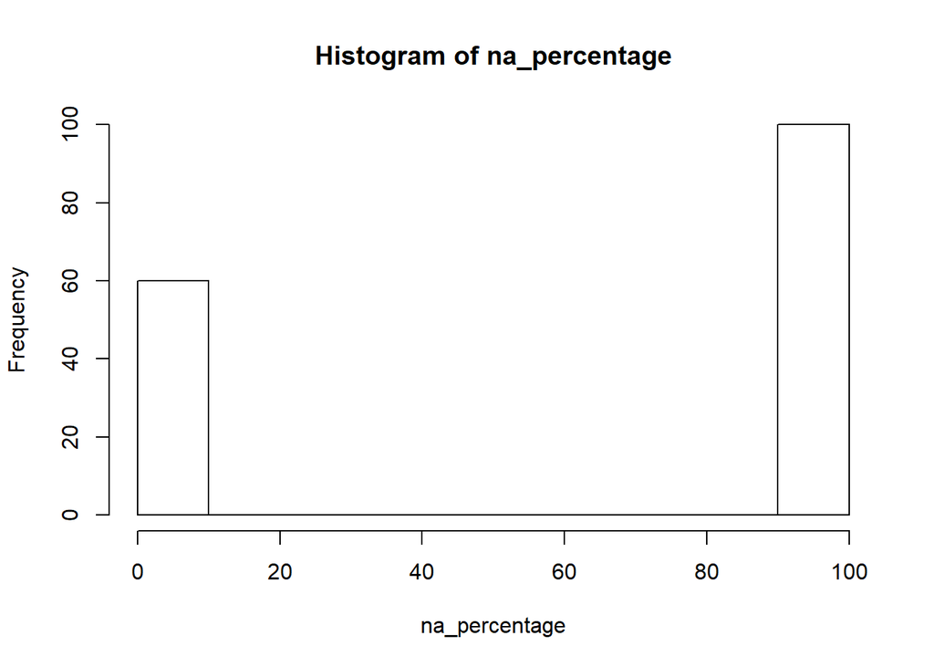

```r
na_percentage <- apply(training, 2, function(x) { 100*sum(is.na(x))/nrow(training)})
hist(na_percentage)
```

```r
subset_vector3 <- na_percentage < 90
```

### Removing irrelevant variables from the data sets

After cleaning the data there are 53 predictors left to build the models.

```r
subset_vector <- subset_vector1 & subset_vector2 & subset_vector3
training <- training[,subset_vector]
testing <- testing[,subset_vector]

dim(training)
```

```
## [1] 19622    54
```

## Setting up the data for model creation

Since it should be possible to predict an out-of-sample error it is necessary to divide the training set further into a training part used for model creation an another part to test the model.

```r
inTrain <- createDataPartition(y=training$classe,p=0.75, list=FALSE)
train <- training[inTrain,]
test <- training[-inTrain,]
```

## Model creation and evaluation

For the models we use 10-fold cross validation to reduce overfitting. Since we use the caret train methods to buid models this replaces the default bootstrap resampling.

```r
tc=trainControl(method="cv", number=10)
```

### Decision Tree

First we use the caret train method to create a decision tree.

```r
moddec <- train(classe ~ ., data=train, method="rpart", trControl=tc)
moddec
```

```
## CART
##
## 14718 samples
##    53 predictor
##     5 classes: 'A', 'B', 'C', 'D', 'E'
##
## No pre-processing
## Resampling: Cross-Validated (10 fold)
## Summary of sample sizes: 13246, 13245, 13247, 13246, 13246, 13248, ...
## Resampling results across tuning parameters:
##
##   cp          Accuracy   Kappa
##   0.03849805  0.5508920  0.42259458
##   0.05568214  0.4243601  0.21996378
##   0.11421248  0.3160193  0.04858448
##
## Accuracy was used to select the optimal model using the largest value.
## The final value used for the model was cp = 0.03849805.
```

The model shows an accuracy of just above 50% on the sample data, we discard this model and don’t use it any further.

### Random Forest

The default configuration of caret using rf is the creation of 500 trees. Given the size of the data set and the number of predictors we create only 10 trees (parameter ntree), to be able to create a model in a reasonable time given the used hardware.

```r
modrf <- train(classe ~ ., data=train, method="rf", trControl=tc, ntree=10)
modrf
```

```
## Random Forest
##
## 14718 samples
##    53 predictor
##     5 classes: 'A', 'B', 'C', 'D', 'E'
##
## No pre-processing
## Resampling: Cross-Validated (10 fold)
## Summary of sample sizes: 13246, 13248, 13246, 13245, 13246, 13244, ...
## Resampling results across tuning parameters:
##
##   mtry  Accuracy   Kappa
##    2    0.9867513  0.9832387
##   27    0.9956510  0.9944989
##   53    0.9934090  0.9916626
##
## Accuracy was used to select the optimal model using the largest value.
## The final value used for the model was mtry = 27.
```

Surprisingly, this algorithm works quite well with an accuracy of above 99%. we proceed to estimate an out-of-sample error using the test set.

```r
pred <- predict(modrf, newdata = test)
confusionMatrix(pred, test$classe)
```

```
## Confusion Matrix and Statistics
##
##           Reference
## Prediction    A    B    C    D    E
##          A 1394    2    0    0    0
##          B    0  947    1    0    1
##          C    0    0  854    8    0
##          D    0    0    0  796    0
##          E    1    0    0    0  900
##
## Overall Statistics
##
##                Accuracy : 0.9973
##                  95% CI : (0.9955, 0.9986)
##     No Information Rate : 0.2845
##     P-Value [Acc > NIR] : < 2.2e-16
##
##                   Kappa : 0.9966
##  Mcnemar's Test P-Value : NA
##
## Statistics by Class:
##
##                      Class: A Class: B Class: C Class: D Class: E
## Sensitivity            0.9993   0.9979   0.9988   0.9900   0.9989
## Specificity            0.9994   0.9995   0.9980   1.0000   0.9998
## Pos Pred Value         0.9986   0.9979   0.9907   1.0000   0.9989
## Neg Pred Value         0.9997   0.9995   0.9998   0.9981   0.9998
## Prevalence             0.2845   0.1935   0.1743   0.1639   0.1837
## Detection Rate         0.2843   0.1931   0.1741   0.1623   0.1835
## Detection Prevalence   0.2847   0.1935   0.1758   0.1623   0.1837
## Balanced Accuracy      0.9994   0.9987   0.9984   0.9950   0.9993
```

```r
accuracy <- confusionMatrix(pred, test$classe)$overall[1]
out_of_sample_error <- 1 - accuracy
```

Using the test set we also see an accuracy of **0.9973491** and an estimated out of sample error of **0.0026509**.

## Prediction on the given testing set

We use the created Random Forest model to make predictions on the given testing set https://d396qusza40orc.cloudfront.net/predmachlearn/pml-testing.csv.

```r
pred_testing <- predict(modrf, newdata = testing)
pred_testing
```

```
##  [1] B A B A A E D B A A B C B A E E A B B B
## Levels: A B C D E
```